# VaR

```python
import pandas as pd
import numpy as np
import matplotlib.pyplot as plt
```

```python
from sklearn.linear_model import LinearRegression
from sklearn.model_selection import train_test_split
from sklearn.metrics import mean_squared_error
```

```python
from scipy import stats
import statsmodels.api as sm
```

### Описание задачи

- Оценить VaR на горизонте 10 дней от вложений в зерно на основе моделирования поведения факторов.

### Импорт данных

Импортируем данные за 2 года и посмотрим на них

```python
brent = pd.read_csv("Brent_Oil_Futures_Historical_Data.csv")
dj = pd.read_csv("Dow_Jones_Industrial_Average_Historical_Data.csv")
tapr = pd.read_csv("TAPR_Historical_Data.csv")
wheat = pd.read_csv("Thomson_Reuters_CoreCommodity_CRB_Wheat_Historical_Data.csv")
```

```python
print("Brent:")
print(brent.describe())
print(brent.columns)
print("Dow Jones:")
print(dj.describe())
print(dj.columns)
print("TAPR:")
print(tapr.describe())
print(tapr.columns)
print("Wheat:")
print(wheat.describe())
print(wheat.columns)
```

```
Brent:
            Price        Open        High        Low
count  524.000000  524.000000  524.000000  524.00000
mean    59.585992   59.543588   60.254504   58.83542
std      9.985415    9.941244    9.986273    9.90612
min     44.430000   44.540000   44.990000   43.57000
25%     51.615000   51.595000   52.175000   50.98750
50%     55.985000   55.980000   56.640000   55.47500
75%     68.392500   68.150000   68.967500   67.62000
max     79.800000   79.650000   80.500000   79.16000
Index(['Date', 'Price', 'Open', 'High', 'Low', 'Vol.', 'Change %'], dtype='object')
Dow Jones:
                Date      Price       Open       High        Low     Vol.  \
count            512        512        512        512        512      512
unique           512        512        512        512        512      506
top     Aug 18, 2017  21,891.12  24,877.36  24,877.36  21,294.09  276.74M
freq               1          1          1          1          1        2

       Change %
count       512
unique      208
top      -0.29%
freq         10
Index(['Date', 'Price', 'Open', 'High', 'Low', 'Vol.', 'Change %'], dtype='object')
TAPR:
            Price        Open        High         Low
count  430.000000  430.000000  430.000000  430.000000
mean    24.547744   24.576093   24.724628   24.380977
std      3.147696    3.156762    3.208516    3.097276
min     16.770000   16.590000   16.970000   16.280000
25%     22.152500   22.175000   22.192500   22.092500
50%     25.235000   25.280000   25.465000   25.075000
75%     27.115000   27.290000   27.435000   26.877500
max     30.390000   30.300000   30.680000   30.000000
Index(['Date', 'Price', 'Open', 'High', 'Low', 'Vol.', 'Change %'], dtype='object')
Wheat:
            Price        Open        High         Low
count  512.000000  512.000000  512.000000  512.000000
mean     1.857913    1.857713    1.876584    1.839926
std      0.135419    0.131305    0.136993    0.130456
min      1.432800    1.436100    1.451500    1.429800
25%      1.780575    1.780075    1.795175    1.763900
50%      1.857750    1.861300    1.875900    1.844800
75%      1.938625    1.930375    1.952100    1.912525
max      2.315600    2.351400    2.387500    2.276800
Index(['Date', 'Price', 'Open', 'High', 'Low', 'Vol.', 'Change %'], dtype='object')
```

Для анализа будем использовать столбцы Date и Price.

Приводим числовые данные - цену Dow Jones - к нужному виду

```python
dj.Price = dj.Price.apply(lambda x: x.replace(',','')).astype(float)
dj.describe()
```

|  | Price |
| --- | --- |
| count | 512.000000 |
| mean | 22260.791738 |
| std | 2427.357129 |
| min | 17888.280000 |
| 25% | 20588.572500 |
| 50% | 21990.635000 |
| 75% | 24616.985000 |
| max | 26616.710000 |

#### Объединение данных в одну таблицу по дате

```python
required_columns = ["Date", "Price"]
data = dj[required_columns]
for df,suffix in zip([brent, tapr, wheat], ["_brent", "_tapr", "_wheat"]):
    data = pd.merge(data, df[required_columns], on="Date", how="outer", suffixes=("", suffix))

data.rename({"Price": "Price_dj"}, axis='columns', inplace=True)
```

```python
data.head()
```

|  | Date | Price_dj | Price_brent | Price_tapr | Price_wheat |
| --- | --- | --- | --- | --- | --- |
| 0 | Aug 31, 2018 | 25964.82 | 77.42 | 25.93 | 1.7810 |
| 1 | Aug 30, 2018 | 25986.92 | 77.77 | 25.99 | 1.7467 |
| 2 | Aug 29, 2018 | 26124.57 | 77.14 | 26.38 | 1.7688 |
| 3 | Aug 28, 2018 | 26064.02 | 75.95 | 26.16 | 1.7084 |
| 4 | Aug 27, 2018 | 26049.64 | 76.21 | 25.90 | 1.7059 |

Приведём дату к нужному типу данных и отсортируем по дате.

```python
data.Date = data.Date.apply(lambda date: pd.datetime.strptime(date, "%b %d, %Y"))
data.sort_values(by='Date', inplace=True)
data.Date.head()
```

```
511   2016-08-22
510   2016-08-23
509   2016-08-24
508   2016-08-25
507   2016-08-26
Name: Date, dtype: datetime64[ns]
```

Посмотрим на изменение цен с течением времени

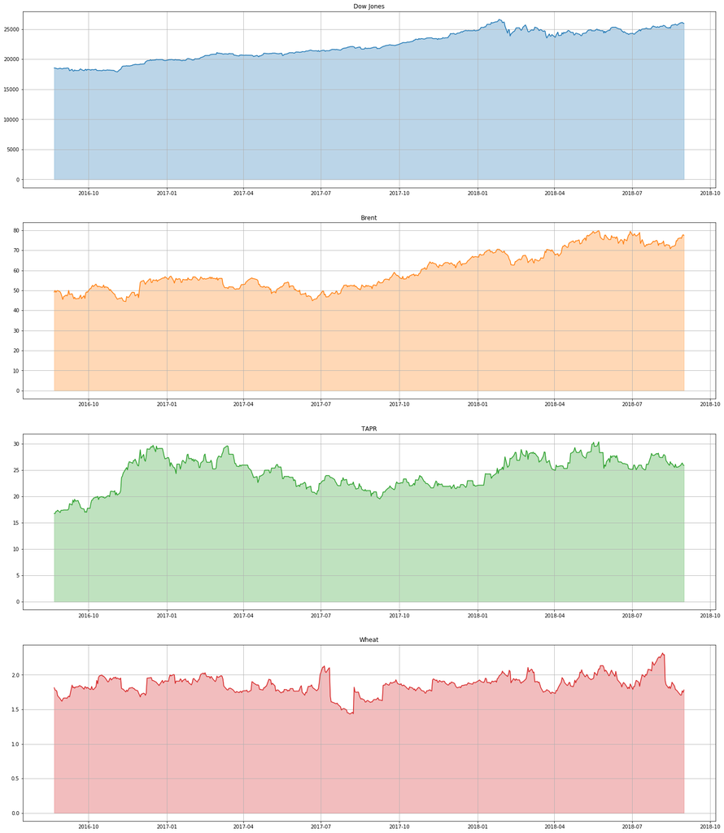

```python
plt.figure(figsize=(25,30))
plt.subplot(4,1,1)
plt.fill_between(data.Date.values, data.Price_dj, alpha=0.3, color='C0')
plt.plot(data.Date.values, data.Price_dj, color='C0')
plt.grid()
plt.title("Dow Jones")
plt.subplot(4,1,2)
plt.fill_between(data.Date.values, data.Price_brent, alpha=0.3, color='C1')
plt.plot(data.Date.values, data.Price_brent, color='C1')
plt.grid()
plt.title("Brent")
plt.subplot(4,1,3)
plt.fill_between(data.Date.values, data.Price_tapr, alpha=0.3, color='C2')
plt.plot(data.Date.values, data.Price_tapr, color='C2')
plt.grid()
plt.title("TAPR")
plt.subplot(4,1,4)
plt.fill_between(data.Date.values, data.Price_wheat, alpha=0.3, color='C3')
plt.plot(data.Date.values, data.Price_wheat, color='C3')
plt.grid()
plt.title("Wheat")
plt.show()
```

### Заполнение пропущенных значений

Посмотрим на строки с пропущенными значениями

```python
data[data.isna().apply(any, axis=1)]
```

|  | Date | Price_dj | Price_brent | Price_tapr | Price_wheat |
| --- | --- | --- | --- | --- | --- |
| 10 | 2018-08-17 | 25669.32 | 71.83 | NaN | 1.8928 |
| 17 | 2018-08-08 | 25583.75 | 72.28 | NaN | 2.2923 |
| 25 | 2018-07-27 | 25451.06 | 74.29 | NaN | 2.1381 |
| 36 | 2018-07-12 | 24924.89 | 74.45 | NaN | 1.9527 |
| 37 | 2018-07-11 | 24700.45 | 73.40 | NaN | 1.9013 |
| 38 | 2018-07-10 | 24919.66 | 78.86 | NaN | 1.8336 |
| 45 | 2018-06-28 | 24216.05 | 77.85 | NaN | 1.8019 |
| 49 | 2018-06-22 | 24580.89 | 75.55 | NaN | 1.8793 |
| 50 | 2018-06-21 | 24461.70 | 73.05 | NaN | 1.8886 |
| 53 | 2018-06-18 | 24987.47 | 75.34 | NaN | 1.8690 |
| 78 | 2018-05-11 | 24831.17 | 77.12 | NaN | 1.9590 |
| 81 | 2018-05-08 | 24360.21 | 74.85 | NaN | 1.9824 |
| 87 | 2018-04-30 | 24163.15 | 75.17 | NaN | 1.9670 |
| 94 | 2018-04-19 | 24664.89 | 73.78 | NaN | 1.8909 |
| 97 | 2018-04-16 | 24573.04 | 71.42 | NaN | 1.8457 |
| 98 | 2018-04-13 | 24360.14 | 72.58 | NaN | 1.8851 |
| 100 | 2018-04-11 | 24189.45 | 72.06 | NaN | 1.9429 |
| 104 | 2018-04-05 | 24505.22 | 68.33 | NaN | 1.8001 |
| 117 | 2018-03-16 | 24946.51 | 66.21 | NaN | 1.8144 |
| 159 | 2018-01-16 | 25792.86 | 69.15 | NaN | 1.8708 |
| 160 | 2018-01-12 | 25803.19 | 69.87 | NaN | 1.8888 |
| 164 | 2018-01-08 | 25283.00 | 67.78 | NaN | 1.8888 |
| 165 | 2018-01-05 | 25295.87 | 67.62 | NaN | 1.9020 |
| 166 | 2018-01-04 | 25075.13 | 68.07 | NaN | 1.9164 |
| 167 | 2018-01-03 | 24922.68 | 67.84 | NaN | 1.9252 |
| 172 | 2017-12-26 | 24746.21 | 67.02 | NaN | 1.8645 |
| 173 | 2017-12-22 | 24754.06 | 65.25 | NaN | 1.8755 |
| 174 | 2017-12-21 | 24782.29 | 64.90 | NaN | 1.8855 |
| 178 | 2017-12-15 | 24651.74 | 63.23 | NaN | 1.8468 |
| 179 | 2017-12-14 | 24508.66 | 63.31 | NaN | 1.8468 |
| ... | ... | ... | ... | ... | ... |
| 340 | 2017-04-27 | 20981.33 | 51.44 | NaN | 1.8317 |
| 344 | 2017-04-21 | 20547.76 | 51.96 | NaN | 1.7881 |
| 354 | 2017-04-06 | 20662.95 | 54.89 | NaN | 1.7527 |
| 355 | 2017-04-05 | 20648.15 | 54.36 | NaN | 1.7790 |
| 356 | 2017-04-04 | 20689.24 | 54.17 | NaN | 1.7683 |
| 357 | 2017-04-03 | 20650.21 | 53.12 | NaN | 1.7708 |
| 358 | 2017-03-31 | 20663.22 | 52.83 | NaN | 1.7657 |
| 364 | 2017-03-23 | 20656.58 | 50.56 | NaN | 1.7429 |
| 368 | 2017-03-17 | 20914.62 | 51.76 | NaN | 1.8060 |
| 393 | 2017-02-09 | 20172.40 | 55.63 | NaN | 1.9736 |
| 423 | 2016-12-27 | 19945.04 | 56.09 | NaN | 1.9200 |
| 466 | 2016-10-25 | 18169.27 | 50.79 | NaN | 1.9051 |
| 500 | 2016-09-07 | 18526.14 | 47.98 | NaN | 1.6780 |
| 501 | 2016-09-06 | 18538.12 | 47.26 | NaN | 1.6603 |
| 503 | 2016-09-01 | 18419.30 | 45.45 | NaN | 1.6446 |
| 504 | 2016-08-31 | 18400.88 | 47.04 | NaN | 1.6176 |
| 508 | 2016-08-25 | 18448.41 | 49.67 | NaN | 1.7655 |
| 510 | 2016-08-23 | 18547.30 | 49.96 | NaN | 1.7811 |
| 512 | 2018-07-04 | NaN | 78.24 | NaN | NaN |
| 513 | 2018-05-28 | NaN | 75.30 | NaN | NaN |
| 514 | 2018-02-19 | NaN | 65.67 | NaN | NaN |
| 515 | 2018-01-15 | NaN | 70.26 | NaN | NaN |
| 516 | 2017-11-23 | NaN | 63.55 | NaN | NaN |
| 517 | 2017-09-04 | NaN | 52.34 | NaN | NaN |
| 518 | 2017-07-04 | NaN | 49.61 | NaN | NaN |
| 519 | 2017-05-29 | NaN | 52.29 | NaN | NaN |
| 520 | 2017-02-20 | NaN | 56.18 | NaN | NaN |
| 521 | 2017-01-16 | NaN | 55.86 | NaN | NaN |
| 522 | 2016-11-24 | NaN | 49.00 | NaN | NaN |
| 523 | 2016-09-05 | NaN | 47.63 | NaN | NaN |

94 rows × 5 columns

Пропущенные значения - в дни национальных праздников и некоторые другие дни - заполним последним непропущенным значением для фактора, т. е. действительной ценой к тому дню, в который у нас нет значения

```python
data.fillna(method="ffill", inplace=True)
```

```python
data.apply(lambda x: all(x.isna()))
```

```
Date           False
Price_dj       False
Price_brent    False
Price_tapr     False
Price_wheat    False
dtype: bool
```

Теперь, когда нет пропущенных значений, преобразуем данные - посчитаем 10-дневную доходность для каждого фактора (в долях)

```python
def count_profit(column, period=10):
    return (column[period:].values - column[:-period].values)/column[:-period].values

profit = pd.DataFrame()
profit["brent"] = count_profit(data.Price_brent)
profit["dj"] = count_profit(data.Price_dj)
profit["tapr"] = count_profit(data.Price_tapr)
profit["wheat"] = count_profit(data.Price_wheat)
```

```python
profit.head()
```

|  | brent | dj | tapr | wheat |
| --- | --- | --- | --- | --- |
| 0 | -0.031123 | -0.002022 | 0.039952 | -0.082718 |
| 1 | -0.054043 | -0.000495 | 0.039952 | -0.067823 |
| 2 | -0.021814 | 0.002416 | 0.015725 | -0.055127 |
| 3 | 0.006443 | 0.001707 | 0.029703 | -0.041914 |
| 4 | -0.038261 | -0.016849 | 0.071264 | -0.009836 |

На этих данных будет обучаться модель

### Линейная модель зависимости инструмента от факторов

Распределения и взаимосвязи между переменными в выборке

[output not shown]

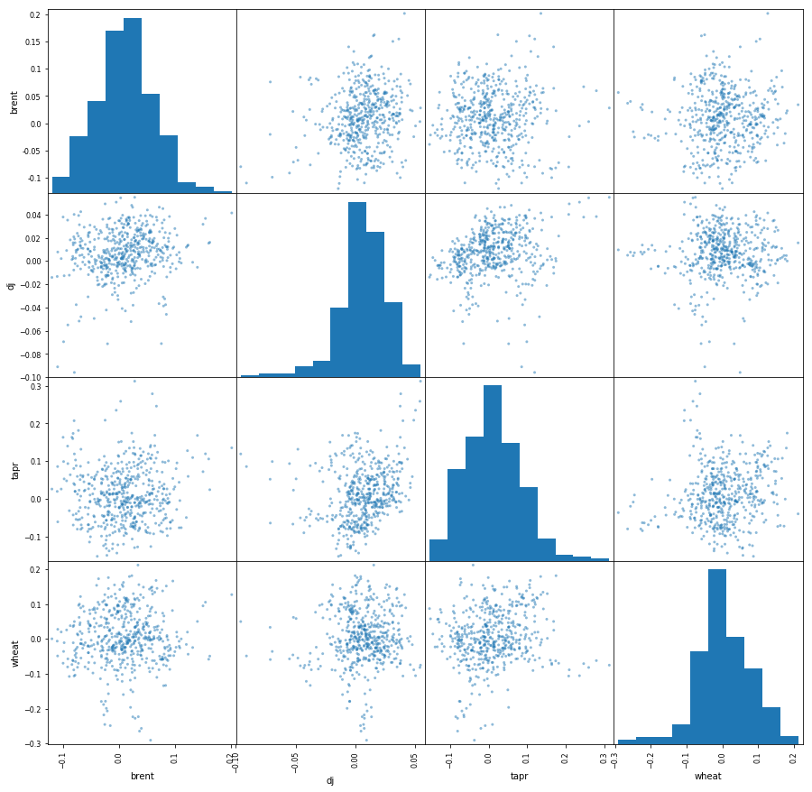

```python
pd.plotting.scatter_matrix(profit, figsize=(15,15))
```

Разобьём данные на обучающую и тестовую выборку

```python
predictors = ["dj", "brent", "tapr"]
X_train, X_test, y_train, y_test = train_test_split(profit[predictors], profit["wheat"], test_size=0.25, shuffle=False)
```

Построим модель - линейную регрессию

```python
model = LinearRegression()
model.fit(X_train, y_train)
```

```
LinearRegression(copy_X=True, fit_intercept=True, n_jobs=1, normalize=False)
```

```python
print("Ошибка на обучающей выборке: {:.6}".format(mean_squared_error(model.predict(X_train), y_train)))
print("Ошибка на тестовой выборке: {:.6}".format(mean_squared_error(model.predict(X_test), y_test)))
```

```
Ошибка на обучающей выборке: 0.00527548
Ошибка на тестовой выборке: 0.00849468
```

```python
print(model.coef_)
print(model.intercept_)
```

```
[-0.52312069  0.18433796  0.07744955]
0.00766095549244
```

#### Анализ модели

```python
X = sm.add_constant(X_train)
statmodel = sm.OLS(y_train, X)
results = statmodel.fit()
```

```python
print(results.summary())
```

```
                            OLS Regression Results
==============================================================================
Dep. Variable:                  wheat   R-squared:                       0.029
Model:                            OLS   Adj. R-squared:                  0.022
Method:                 Least Squares   F-statistic:                     3.826
Date:                Mon, 03 Sep 2018   Prob (F-statistic):             0.0101
Time:                        21:30:43   Log-Likelihood:                 463.31
No. Observations:                 385   AIC:                            -918.6
Df Residuals:                     381   BIC:                            -902.8
Df Model:                           3
Covariance Type:            nonrobust
==============================================================================
                 coef    std err          t      P>|t|      [0.025      0.975]
------------------------------------------------------------------------------
const          0.0077      0.004      1.876      0.061      -0.000       0.016
dj            -0.5231      0.206     -2.545      0.011      -0.927      -0.119
brent          0.1843      0.072      2.566      0.011       0.043       0.326
tapr           0.0774      0.051      1.525      0.128      -0.022       0.177
==============================================================================
Omnibus:                       30.511   Durbin-Watson:                   0.278
Prob(Omnibus):                  0.000   Jarque-Bera (JB):               69.903
Skew:                          -0.403   Prob(JB):                     6.62e-16
Kurtosis:                       4.925   Cond. No.                         55.6
==============================================================================

Warnings:
[1] Standard Errors assume that the covariance matrix of the errors is correctly specified.
```

Выводы:

- маленький коэффициент детерминации говорит о том, что построенная модель не улавливает изменения целевой переменной. Для более корректного анализа необходимо использовать другую модель.
- коэффициенты при dj и brent значимы на уровне alpha = 0.05

### Оценка параметров распределений факторов и генерация значений

Оценим необходимые параметры распределений факторов по имеющейся выборке: выборочное среднее, дисперсию, корреляции (ковариации).

```python
means = profit[predictors].apply(stats.tmean)
stds = profit[predictors].apply(stats.tstd)
covs = profit[predictors].cov()
```

Создадим распределение и сгенерируем N = 500 новый значений

```python
factors_distr = stats.multivariate_normal(means, covs)
```

```python
N = 500
np.random.seed(42)
random_factors = factors_distr.rvs(size=N)
```

Вычислим значение wheat с помощью построенной линейной модели

```python
prediction = model.predict(random_factors)
```

### Оценка значений VaR и CVaR

Оценим значения VaR и CVar по получившемуся эмпирическому распределению

```python
def get_VaR(factor):
    return np.percentile(prediction,1)
VaR = get_VaR(prediction)
print("VaR: {:.6}".format(VaR))
```

```
VaR: -0.023822
```

```python
def get_CVaR(factor, VaR=None):
    if not(VaR):
       VaR = get_VaR(factor)
    below_var = prediction[prediction <= VaR]
    return np.mean(below_var)
CVaR = get_CVaR(prediction, VaR)
print("CVaR: {:.6}".format(CVaR))
```

```
CVaR: -0.0279352
```

Изобразим получившиеся значения на графике

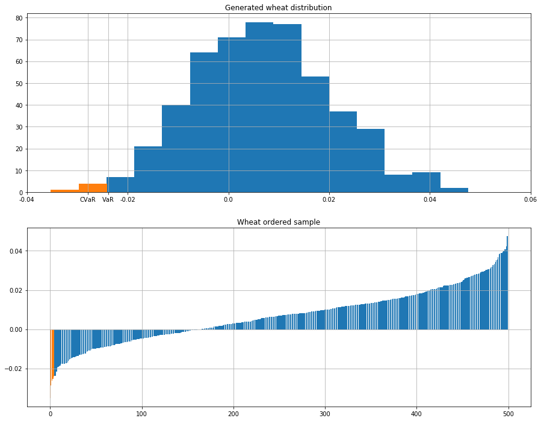

```python
below_var = prediction[prediction <= VaR]
plt.figure(figsize=(15,12))
ax = plt.subplot(2,1,1)
plt.hist(prediction,bins=15)
plt.hist(below_var, bins=2)
plt.grid()
plt.title("Generated wheat distribution")
ticks = ax.get_xticks()
tickls = ax.get_xticklabels()
ax.set_xticks(np.append(ticks,[VaR, CVaR]))
ax.set_xticklabels(np.append(np.round(ticks,2),["VaR", "CVaR"]))
plt.subplot(2,1,2)
plt.bar(x=range(len(prediction)),height=np.sort(prediction))
plt.bar(x=range(len(below_var)),height=np.sort(below_var))
plt.grid()
plt.title("Wheat ordered sample")
plt.show()
```

### Оценка вероятностного интервала значений VaR и CVaR

Так как мы не предполагаем ничего о распределении инструмента wheat, сгенерируем много выборок размера N, на каждой выборке получим ответ модели и значения VaR и CVaR. Затем построим эмпирические плотности распределений для этих параметров и по ним рассчитаем доверительный интервал.

```python
M = 500 # количество симуляций
np.random.seed(0)
VaRs = np.zeros(M)
CVaRs = np.zeros(M)
for i in range(M):
    factors = factors_distr.rvs(N)
    prediction = model.predict(factors)
    VaR = get_VaR(prediction)
    CVaR = get_CVaR(prediction, VaR)
    VaRs[i] = VaR
    CVaRs[i] = CVaR
```

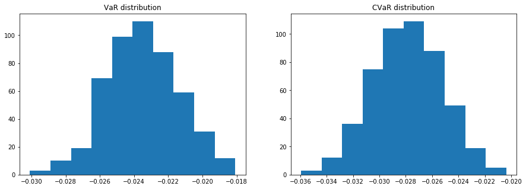

```python
plt.figure(figsize=(15,5))
plt.subplot(1,2,1)
plt.hist(VaRs)
plt.title("VaR distribution")
plt.subplot(1,2,2)
plt.hist(CVaRs)
plt.title("CVaR distribution")
plt.show()
```

```python
alpha = 0.01
print("Вероятностный {:d}% интервал для VaR: [{:.6}, {:.6}]".format(
    round((1-alpha)*100), np.percentile(VaRs, alpha/2), np.percentile(VaRs, 1-alpha/2)))
print("Вероятностный {:d}% интервал для CVaR: [{:.6}, {:.6}]".format(
    round((1-alpha)*100), np.percentile(CVaRs, alpha/2), np.percentile(CVaRs, 1-alpha/2)))
```

[output not shown]